# Homework 5

Joe Dickerson

2025-02-14

```r
library(faraway)
library(tidyverse)
data(esdcomp)
```

1. Consider the rate of complaints in terms of the number received in relation to the number of patient visits made. Plot this against each of the four potential predictors and comment on the relationships.

We see similar means but a higher range between doctors in their residency and doctors not in their residency when looking at rate of complaints. We see similar findings when comparing gender to rate of complaints, however the minimum is a bit higher for the female doctors than the male. There are approximately 1/3 the amount of female doctors in the study, however, so this may not be as significant. It seems there is a somewhat noticeable relationship between hours worked and rate of complaints.

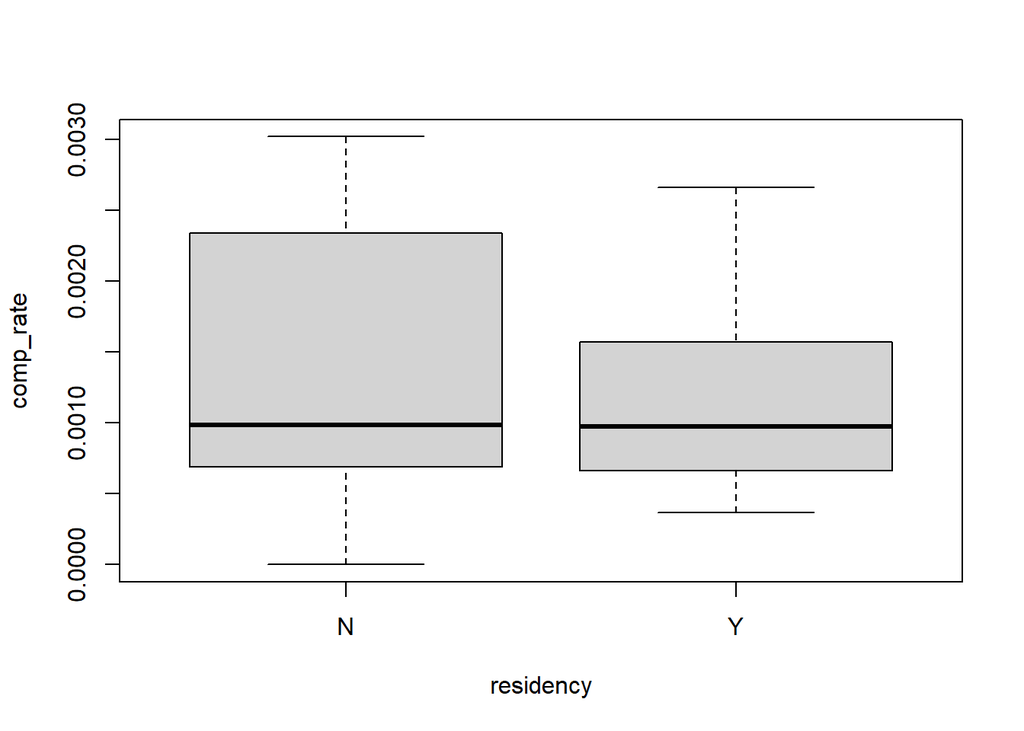

```r
comp_rate <- esdcomp$complaints/esdcomp$visits

plot(comp_rate ~ residency, esdcomp)
```

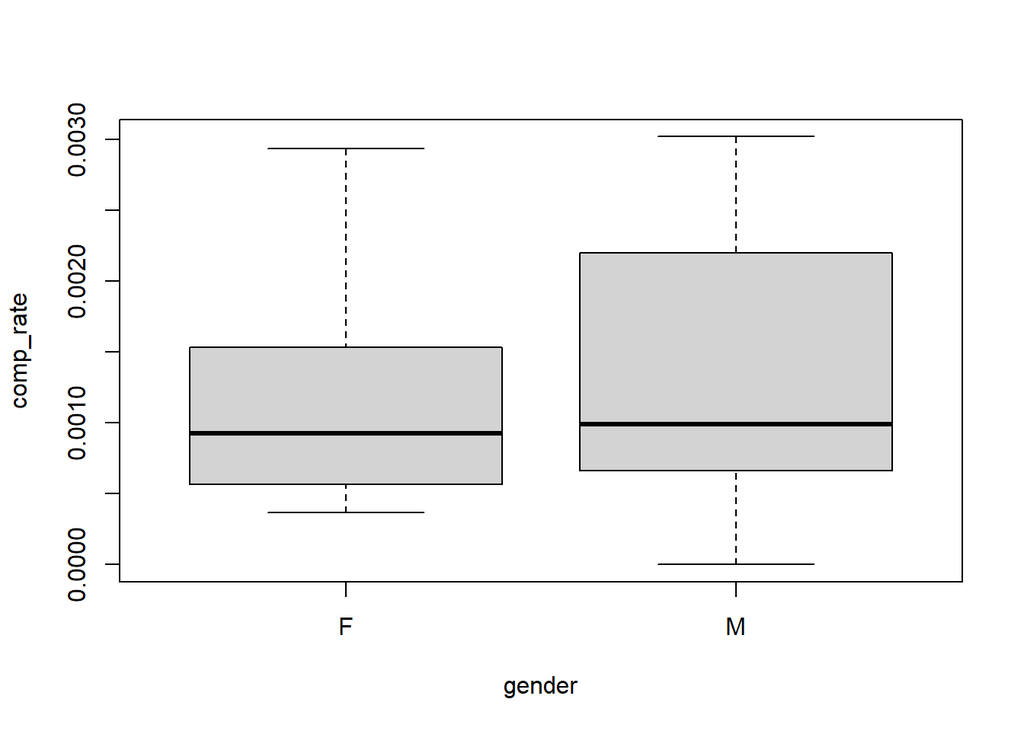

```r
plot(comp_rate ~ gender, esdcomp)
```

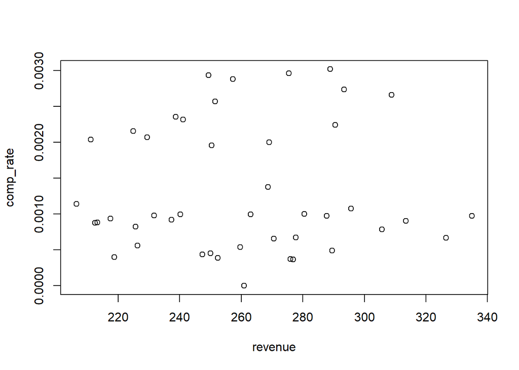

```r
plot(comp_rate ~ revenue, esdcomp)
```

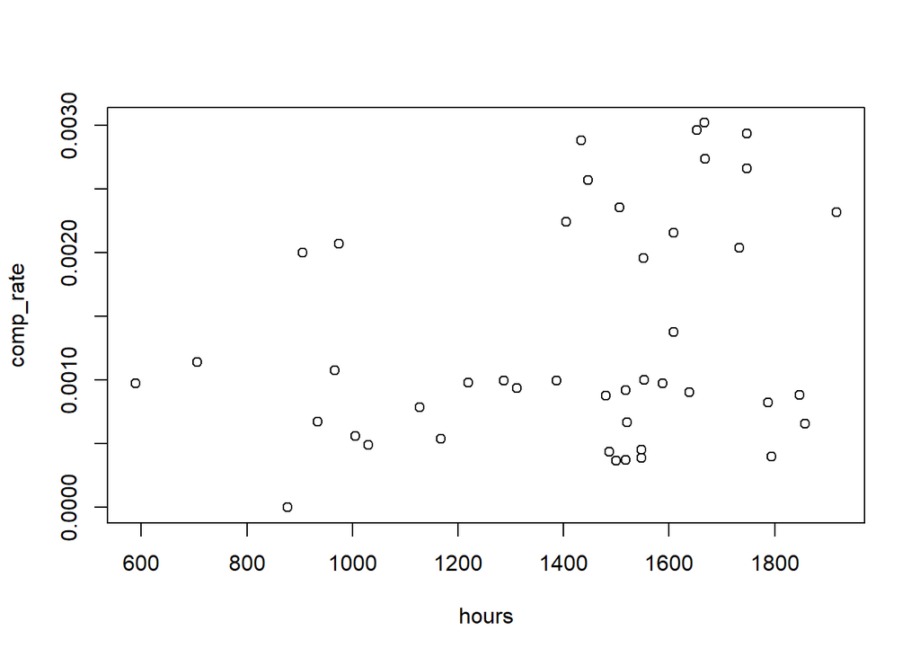

```r
plot(comp_rate ~ hours, esdcomp)
```

2. Fit a binomial GLM for the number of complaints out of the number of visits with the other four variables as predictors. Does this model fit the data? Perform this check numerically and graphically.

It does not appear the model fits the data well. There is not much significance in the predictors, aside from hours worked with a decent p-value of 0.0451. Our residuals vs fitted plot looks acceptable, but looking at the fitted vs observed results, there does not appear to be a linear relationship.

```r
bimod <- glm(cbind(complaints, visits - complaints) ~ ., family = binomial, esdcomp)

summary(bimod)
```

```
##
## Call:
## glm(formula = cbind(complaints, visits - complaints) ~ ., family = binomial,
##     data = esdcomp)
##
## Coefficients:
##               Estimate Std. Error z value Pr(>|z|)
## (Intercept) -8.1208523  0.8508618  -9.544   <2e-16 ***
## residencyY  -0.2092939  0.2012992  -1.040   0.2985
## genderM      0.1956918  0.2182965   0.896   0.3700
## revenue      0.0015785  0.0028317   0.557   0.5772
## hours        0.0007028  0.0003508   2.004   0.0451 *
## ---
## Signif. codes:  0 '***' 0.001 '**' 0.01 '*' 0.05 '.' 0.1 ' ' 1
##
## (Dispersion parameter for binomial family taken to be 1)
##
##     Null deviance: 63.523  on 43  degrees of freedom
## Residual deviance: 54.594  on 39  degrees of freedom
## AIC: 187.31
##
## Number of Fisher Scoring iterations: 5
```

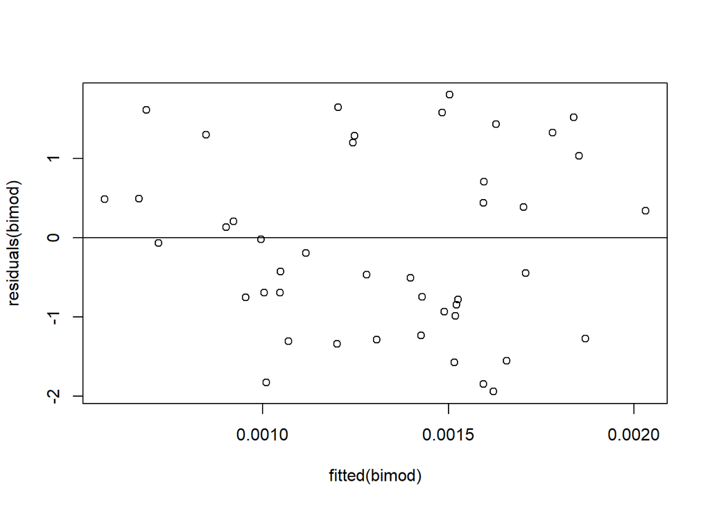

```r
plot(residuals(bimod) ~ fitted(bimod))
abline(h=0)
```

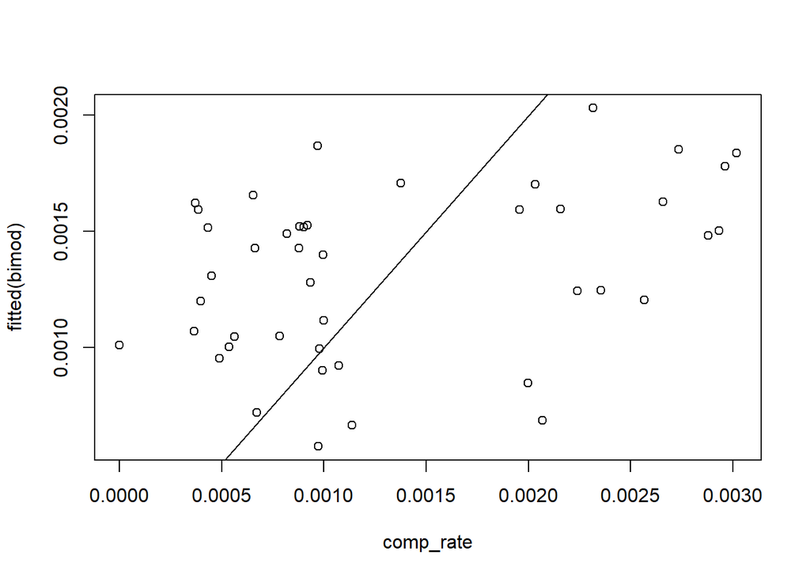

```r
plot(comp_rate, fitted(bimod))
abline(a=0, b=1)
```

3. Check the significance of the four predictors in the binomial model. Give a numerical interpretation to the effect of any significant predictors.

The only predictor with significance is hours with a p-value of 0.0451. It seems to suggest that the rate of complaints will increase by 0.0007 for each additional hour worked with the other variables remaining unchanged.

```r
summary(bimod)
```

```
##
## Call:
## glm(formula = cbind(complaints, visits - complaints) ~ ., family = binomial,
##     data = esdcomp)
##
## Coefficients:
##               Estimate Std. Error z value Pr(>|z|)
## (Intercept) -8.1208523  0.8508618  -9.544   <2e-16 ***
## residencyY  -0.2092939  0.2012992  -1.040   0.2985
## genderM      0.1956918  0.2182965   0.896   0.3700
## revenue      0.0015785  0.0028317   0.557   0.5772
## hours        0.0007028  0.0003508   2.004   0.0451 *
## ---
## Signif. codes:  0 '***' 0.001 '**' 0.01 '*' 0.05 '.' 0.1 ' ' 1
##
## (Dispersion parameter for binomial family taken to be 1)
##
##     Null deviance: 63.523  on 43  degrees of freedom
## Residual deviance: 54.594  on 39  degrees of freedom
## AIC: 187.31
##
## Number of Fisher Scoring iterations: 5
```

4. Fit an appropriate Poisson rate model for number of complaints that takes a comparable form to the binomial GLM fitted earlier. Does this model fit the data? Again check this numerically and graphically.

```r
pmod <- glm(complaints ~ offset(log(visits)) + residency + gender + revenue + hours, family = poisson, esdcomp)

summary(pmod)
```

```
##
## Call:
## glm(formula = complaints ~ offset(log(visits)) + residency +
##     gender + revenue + hours, family = poisson, data = esdcomp)
##
## Coefficients:
##               Estimate Std. Error z value Pr(>|z|)
## (Intercept) -8.1202460  0.8502806  -9.550   <2e-16 ***
## residencyY  -0.2090058  0.2011520  -1.039   0.2988
## genderM      0.1954338  0.2181525   0.896   0.3703
## revenue      0.0015761  0.0028294   0.557   0.5775
## hours        0.0007019  0.0003505   2.002   0.0452 *
## ---
## Signif. codes:  0 '***' 0.001 '**' 0.01 '*' 0.05 '.' 0.1 ' ' 1
##
## (Dispersion parameter for poisson family taken to be 1)
##
##     Null deviance: 63.435  on 43  degrees of freedom
## Residual deviance: 54.518  on 39  degrees of freedom
## AIC: 187.3
##
## Number of Fisher Scoring iterations: 5
```

```r
pchisq(deviance(pmod), df.residual(pmod), lower = FALSE)
```

```
## [1] 0.05051376
```

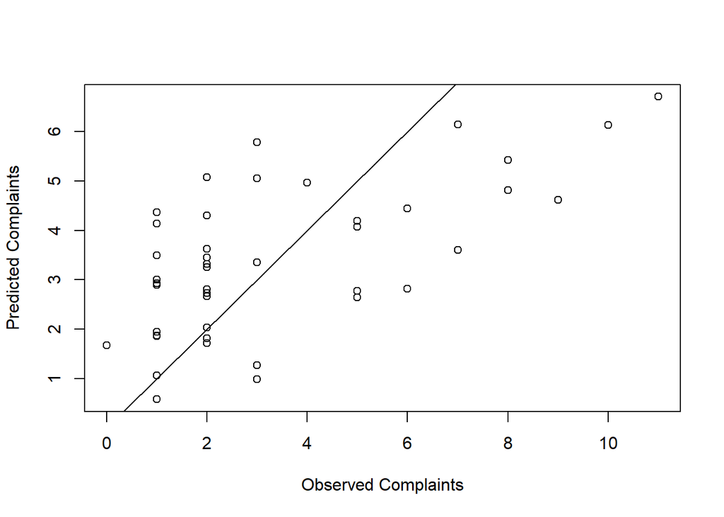

```r
plot(esdcomp$complaints, fitted(pmod), xlab="Observed Complaints", ylab="Predicted Complaints")
abline(a=0, b=1)
```

5. Again check the significance of the predictors and provide a numerical interpretation. Compare the conclusions of the two models.

```r
summary(pmod)
```

```
##
## Call:
## glm(formula = complaints ~ offset(log(visits)) + residency +
##     gender + revenue + hours, family = poisson, data = esdcomp)
##
## Coefficients:
##               Estimate Std. Error z value Pr(>|z|)
## (Intercept) -8.1202460  0.8502806  -9.550   <2e-16 ***
## residencyY  -0.2090058  0.2011520  -1.039   0.2988
## genderM      0.1954338  0.2181525   0.896   0.3703
## revenue      0.0015761  0.0028294   0.557   0.5775
## hours        0.0007019  0.0003505   2.002   0.0452 *
## ---
## Signif. codes:  0 '***' 0.001 '**' 0.01 '*' 0.05 '.' 0.1 ' ' 1
##
## (Dispersion parameter for poisson family taken to be 1)
##
##     Null deviance: 63.435  on 43  degrees of freedom
## Residual deviance: 54.518  on 39  degrees of freedom
## AIC: 187.3
##
## Number of Fisher Scoring iterations: 5
```

```r
exp(pmod$coefficients)
```

```
##  (Intercept)   residencyY      genderM      revenue        hours
## 0.0002974555 0.8113905281 1.2158382834 1.0015773867 1.0007021496
```

6. Exchange the role of hours and visits in the Poisson rate model. Again check the significance of the predictors and interpret the outcome.

We have a notable significance with visits with a p-value of 0.00237. A graphical check reveals a satisfactory trend as well. It appears a one unit change in visits will have 1.0006 higher expected count of complaints.

```r
pmod1<-glm(complaints ~ offset(log(hours)) + residency + gender + revenue + visits, family=poisson, esdcomp)

summary(pmod1)
```

```
##
## Call:
## glm(formula = complaints ~ offset(log(hours)) + residency + gender +
##     revenue + visits, family = poisson, data = esdcomp)
##
## Coefficients:
##               Estimate Std. Error z value Pr(>|z|)
## (Intercept) -7.4904751  0.6855108 -10.927  < 2e-16 ***
## residencyY  -0.1753176  0.1973189  -0.888  0.37427
## genderM      0.1890678  0.2160386   0.875  0.38149
## revenue     -0.0003377  0.0033956  -0.099  0.92077
## visits       0.0005593  0.0001840   3.040  0.00237 **
## ---
## Signif. codes:  0 '***' 0.001 '**' 0.01 '*' 0.05 '.' 0.1 ' ' 1
##
## (Dispersion parameter for poisson family taken to be 1)
##
##     Null deviance: 69.659  on 43  degrees of freedom
## Residual deviance: 52.181  on 39  degrees of freedom
## AIC: 184.96
##
## Number of Fisher Scoring iterations: 5
```

```r
exp(pmod1$coefficients)
```

```
##  (Intercept)   residencyY      genderM      revenue       visits
## 0.0005583776 0.8391904494 1.2081228919 0.9996623240 1.0005594222
```

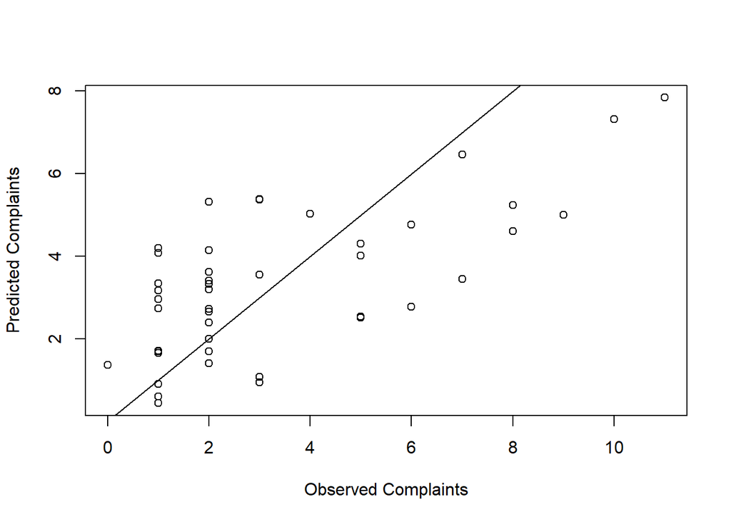

```r
plot(esdcomp$complaints, fitted(pmod1), xlab="Observed Complaints", ylab="Predicted Complaints")
abline(a=0, b=1)
```

7. Compare the two proposed rate models.